# Rによる機械学習 Naive Bayes

Cho（ztempest0218@gmail.com）

Last Updated: 2026-11-05

**データのダウンロード**

Kaggleの迷惑メール分類データを使う。保存先は、講義のプロジェクトフォルダを基準にする。

- **演習データ**：email-spam-kaggle.csv を `data/mail/` に保存する。

**今回の内容**

- 条件付き確率とベイズの定理
- 条件付き独立とBernoulli Naive Bayes
- パラメータの推定とLaplace平滑化
- Rによる迷惑メールの分類・評価と単語の可視化

# 1 迷惑メールの分類

前回のLogistic回帰では、特徴量 $X_i$ から、目的変数 $y_i$ が1となる確率を求めた。今回のNaive Bayesも、目的変数 $y$ がカテゴリである分類に用いる。$y$ の二値分類にも、三つ以上の多値分類にも使える。特徴量 $x$ が離散値か連続値かに応じて、各クラスのもとでの特徴量の分布を選ぶ必要がある。

Naive Bayesの代表的な応用例に、生成AIの普及以前から研究されてきた**迷惑メールの分類**がある。「無料」という言葉は迷惑メールだけでなく、大学からの「無料講座のご案内」にも使われるため、一つの単語だけで機械的に分類すると誤分類が多くなる可能性がある。

今回は、迷惑メールと通常メールで単語が使われる割合から、メールが迷惑メールである確率を求める。まず、単語の「あり／なし」を特徴量とする **Bernoulli Naive Bayes** を2×2表から考えよう。

## 1.1 目的変数と特徴量

**メール本文のような文章は**、行と列に整理された表ではない**非構造化データ**である。分析に使うには、単語を取り出し、その単語が含まれるかどうかなどを変数にする前処理が必要になる。ここでは、メール本文を前処理し、1通を1行として、単語のあり／なしと、あらかじめ判定されたメールの種類（目的変数 $y$）を列に持つ構造化データが用意されていると仮定する。本文から特徴量を作る方法は、後半のR実習で扱う。

教師あり学習で使う目的変数 $y$ の正解ラベルは、人がデータを確認し、手作業で付けることが多い。この作業を**ラベル付け（labeling）**といい、専門に手がける会社もある。例えば、サンフランシスコの **Scale AI** は、2025年6月のMetaによる投資で、企業価値が290億ドル超と評価された。

メール $i$ の目的変数を $y_i$、特徴量を $X_i=(x_{i1},\ldots,x_{id})$ とする。$i$ はメールの番号、$j$ は特徴量の番号、$d$ は使う特徴量の数である。今回は、一つの特徴量を、一つの単語が本文に含まれるかどうかで表す。

まずは、「無料」という一つの単語だけを使う。

$$y_i=\begin{cases}
1 & \text{迷惑メール（spam）}\\
0 & \text{通常メール（ham）}
\end{cases}
\qquad
x_{i1}=\begin{cases}
1 & \text{「無料」あり}\\
0 & \text{「無料」なし}
\end{cases}$$

ここでの $x_{i1}$ は、メール $i$ の第1の特徴量である。「無料」が1回でも3回でも、値は1とする。出現回数は、今回は使わない。

予測したい確率も、前回と同じく $p_i=P(y_i=1\mid X_i)$ と書く。学習データから求めた予測確率は $\hat p_i$、予測クラスは $\hat y_i$ とする。実際の結果 $y_i$ と、その予測確率 $\hat p_i$ を区別しよう。

## 1.2 2×2のクロス集計表

今回は、メールの前処理と正解ラベルの付与がすでに済んだデータを使う。架空のメール20通を学習データとし、本文に「無料」があるかどうかを集計すると、表1のようになる。

表1：メールの種類と「無料」の有無（単位：通）

|  | 「無料」あり $x_1=1$ | 「無料」なし $x_1=0$ | 合計 |
| --- | --- | --- | --- |
| 迷惑メール $y=1$ | 6 | 2 | 8 |
| 通常メール $y=0$ | 3 | 9 | 12 |
| 合計 | 9 | 11 | 20 |

表1の20通で得た割合が、そのまま実際の受信メール全体でも成立するとは限らない。

### 条件付き確率

表1から、「迷惑メールのうち、無料という言葉がある割合」を求める。この場合は、迷惑メール8通を分母にする。

$$\widehat P(x_1=1\mid y=1)=\frac{6}{8}=0.75$$

**学習データ**では、メールの種類がすでに分かっているため、迷惑メールの中で「無料」が使われる割合を集計し、この条件付き確率を推定できる。

一方、**未知データ**では、「無料」があるかどうかは分かっても、迷惑メールかどうかはまだ分からない。予測に使いたいのは、「無料」があるメールが迷惑メールである確率である。表1の学習データでは、「無料」がある9通のうち6通が迷惑メールなので、この割合は次のように求められる。

$$\widehat P(y=1\mid x_1=1)=\frac{6}{9}\approx0.667\tag{1}$$

この0.667は、正解の $y$ が分かっている学習データから求めた割合である。未知のメールでは $y$ が分からないため、学習データのクラス別の割合と**ベイズの定理**を使って、迷惑メールである確率を予測する。

### ベイズの定理

まず、一般的なベイズの定理を復習しよう。二つの事象を $A$、$B$ とすると、条件付き確率の定義から、両方が起こる確率は次の二通りに表せる。

$$P(A\cap B)=P(B\mid A)P(A)=P(A\mid B)P(B)$$

$P(A)>0$、$P(B)>0$ のとき、この式を整理すると、**ベイズの定理（Bayes’ theorem）**が得られる。

$$P(A\mid B)=\frac{P(B\mid A)P(A)}{P(B)}$$

つまり、$B$ が起きたときの $A$ の確率を、$A$ が起きたときの $B$ の確率と、それぞれの事象の確率から求められる。

メールの例では、$A$ を「迷惑メール」、$B$ を「無料という言葉がある」と考える。ベイズの定理に当てはめると、次のようになる。

$$P(y=1\mid x_1=1)
=\frac{P(x_1=1\mid y=1)P(y=1)}{P(x_1=1)}\tag{2}$$

式(2)の各確率を、表1の割合で推定してみよう。

$$\widehat P(y=1\mid x_1=1)
=\frac{(6/8)(8/20)}{9/20}
=\frac{6}{9}\approx0.667$$

式(1)と同じ学習データを使っているため、ベイズの定理からも同じ結果が得られる。

表2：ベイズの定理に出てくる確率

| 名前 | 記号 | 今回の意味 | 表1の推定値 |
| --- | --- | --- | --- |
| 事後確率 （posterior） | $P(y=1\mid x_1=1)$ | 「無料」があるメールが迷惑メールである確率 | $6/9$ |
| 尤度 （likelihood） | $P(x_1=1\mid y=1)$ | 迷惑メールに「無料」が現れる確率 | $6/8$ |
| 事前確率 （prior） | $P(y=1)$ | 迷惑メールの割合 | $8/20$ |
| 周辺確率 | $P(x_1=1)$ | 「無料」が現れる確率 | $9/20$ |

表2の確率に関する用語は、各自で復習してほしい。今回は、尤度・事前確率・周辺確率から**事後確率を求め**、「無料」があるメールが迷惑メールである確率を予測する。

注：尤度 $P(x_1\mid y)$ と、予測したい事後確率 $P(y\mid x_1)$ は異なる。

### 周辺確率の求め方

周辺確率は、すべてのクラスの尤度 × 事前確率を足し合わせて求める。

$$P(X)=\sum_k P(X\mid y=k)P(y=k)$$

表1では、「無料」がある確率は次のようになる。

$$\widehat P(x_1=1)
=\frac{6}{8}\frac{8}{20}+\frac{3}{12}\frac{12}{20}
=\frac{9}{20}$$

この値を分母に使うと、事後確率は $(6/20)/(9/20)=6/9$ となる。各クラスの尤度 × 事前確率を、その合計で割る操作を**正規化**という。

この周辺確率の求め方は、2.3節の予測確率の計算でも使う。

### 事後確率の計算

表1の数値を初期値として、事前確率と尤度を変え、事後確率の変化を見てみよう。通常メールに「無料」がある割合は25%に固定し、周辺確率は自動で計算する。

事前確率（迷惑メールの割合）： 40% 尤度（迷惑メールに「無料」がある割合）： 75%

周辺確率（「無料」がある割合）： 45.0%

事後確率： 66.7%

# 2 複数の特徴量とNaive Bayes

## 2.1 単語の組み合わせ

次に「無料」のほかに「当選」という単語も使う。メール $i$ に「当選」があれば $x_{i2}=1$、なければ $x_{i2}=0$ とする。特徴量は二つになり、$X_i=(x_{i1},x_{i2})$、$d=2$ である。表1の20通を、二つの単語の組み合わせで分けたものが表3である。

表3：「無料」と「当選」の組み合わせ（単位：通）

|  | 無料あり 当選あり $(1,1)$ | 無料あり 当選なし $(1,0)$ | 無料なし 当選あり $(0,1)$ | 両方なし $(0,0)$ | 合計 |
| --- | --- | --- | --- | --- | --- |
| 迷惑メール $y=1$ | 3 | 3 | 1 | 1 | 8 |
| 通常メール $y=0$ | 1 | 2 | 2 | 7 | 12 |
| 合計 | 4 | 5 | 3 | 8 | 20 |

式(2)も、二つの特徴量を使う形に書き換えられる。例えば、「無料」と「当選」が同時に現れる場合、迷惑メールである確率は次のように計算できる。

$$P(y=1\mid x_1=1,x_2=1)
=\frac{P(x_1=1,x_2=1\mid y=1)P(y=1)}{P(x_1=1,x_2=1)}$$

表3の割合を代入すると、

$$\widehat P(y=1\mid x_1=1,x_2=1)
=\frac{(3/8)(8/20)}{4/20}
=\frac{3}{4}=0.75$$

二つの単語なら、この表を使って予測できる。しかし、単語が20個になると、あり／なしの組み合わせは $2^{20}=1,048,576$ 通りになる。第3回の「次元の呪い」と同じく、特徴量を増やすほど組み合わせが増え、少ないデータでは多くの組み合わせが未観測になる。

## 2.2 条件付き独立

そこで、単語ごとに表を作り、その確率を組み合わせる方法を考える。表3から、各クラスで「無料」がある確率と「当選」がある確率は、それぞれ推定できる。

表4：単語ごとの出現確率の推定値

| クラス | 「無料」あり | 「当選」あり |
| --- | --- | --- |
| 迷惑メール $y=1$ | $6/8$ | $4/8$ |
| 通常メール $y=0$ | $3/12$ | $3/12$ |

ただし、単語ごとの確率を知っていても、二つが**同時に現れる確率**は求められない。単語ごとに集計すると、二つが同時に現れたメールの内訳が分からなくなるためである。ここで、**クラスを条件とすると、特徴量同士は独立である**と仮定する。これを条件付き独立（conditional independence）という。

つまり、同じクラスの中では、一つの単語の有無によって、別の単語が現れる確率は変わらないと仮定する。

クラスを表す記号を $c\in\{0,1\}$ と置く。$c=0$ は通常メール、$c=1$ は迷惑メールである。任意の値 $a,b\in\{0,1\}$ に対して、

$$P(x_1=a,x_2=b\mid y=c)
=\underbrace{P(x_1=a\mid y=c)}_{①}\underbrace{P(x_2=b\mid
y=c)}_{②}\tag{3}$$

と仮定する。「無料あり・当選あり」なら $a=b=1$ を代入する。このように、クラスごとの特徴量の分布を独立として扱い、ベイズの定理で分類する方法を**Naive Bayes（ナイーブベイズ）**という。Naiveは、この単純化した独立性の仮定を指す。この仮定により、式(3)のように同時に現れる確率を各特徴量の確率の積として計算できる。特徴量が増えた場合も、同様に各特徴量の確率を掛け合わせる形に拡張できる。

統計学では、カテゴリ変数同士の独立性を$\chi^2$ 検定などで調べることが普通である。一方、Naive Bayesでは条件付き独立を仮定することで計算を簡単にできるメリットがある。この仮定が完全には成り立たなくても、良い予測が得られる場合がある。機械学習では、学習に使っていないテストデータの正解ラベルと予測結果を比較して、予測性能を評価することを重視する。

## 2.3 二つの単語から予測確率を求める

「無料」も「当選」もある新しいメールを考える。予測対象を1通に固定して、クラス $c$ のスコアを $s_c$ と書く。表4の確率と、$y$ の各クラスの割合を掛け合わせると、

$$\begin{aligned}
s_1&=\underbrace{\frac{8}{20}}_{\text{迷惑メールの割合}}
\times\underbrace{\frac{6}{8}}_{\text{無料あり}}
\times\underbrace{\frac{4}{8}}_{\text{当選あり}}=0.15,\\[6pt]
s_0&=\underbrace{\frac{12}{20}}_{\text{通常メールの割合}}
\times\underbrace{\frac{3}{12}}_{\text{無料あり}}
\times\underbrace{\frac{3}{12}}_{\text{当選あり}}=0.0375
\end{aligned}$$

となる。$s_1$ と $s_0$ は、まだ合計が1になっていない。これらを合計で割る操作を**正規化（normalization）**といい、迷惑メールの予測確率は、

$$\hat p=\frac{s_1}{s_0+s_1}
=\frac{0.15}{0.0375+0.15}=0.8$$

通常メールの予測確率は $1-\hat p=0.2$ になる。ここでの正規化は、確率の合計を1にする操作であり、第4回のz-score標準化やmin-maxスケーリングなど、特徴量の尺度を変換する方法とは異なる。

## 2.4 単語の非出現確率を求める

「無料」はあるが、「当選」はないメールでは、$x_1=1,x_2=0$ となる。表4から「当選なし」の確率を計算し、対応する項を入れ替える。

$$\begin{aligned}
s_1&=\frac{8}{20}\times\frac{6}{8}\times\left(1-\frac{4}{8}\right)=0.15,\\
s_0&=\frac{12}{20}\times\frac{3}{12}\times\left(1-\frac{3}{12}\right)=0.1125
\end{aligned}$$

したがって、$\hat p=0.15/(0.15+0.1125)\approx0.571$ となる。「当選」がないため、両方ある場合の80%より低い予測確率になる。

今回のように、単語ごとのあり／なしを使うモデルを**Bernoulli Naive Bayes**という。語彙として選んだ単語について、現れた場合も、現れなかった場合も、その確率を使う。

# 3 パラメータの推定と分類

## 3.1 学習するパラメータ

これまでの計算を、特徴量が $d$ 個の場合にも使える形に整理しよう。クラスの事前確率を $\pi_c$、クラス $c$ で第 $j$ の単語が現れる確率を $\theta_{jc}$ と書く。

$$\pi_c=P(y=c),\qquad
\theta_{jc}=P(x_j=1\mid y=c),\qquad
c\in\{0,1\},\quad j=1,\ldots,d$$

$\theta_{jc}$ の最初の添字は単語、二つ目はクラスである。例えば、$\theta_{1,1}$ は迷惑メールで「無料」が現れる確率、$\theta_{2,0}$ は通常メールで「当選」が現れる確率を表す。$\theta_{jc}$ はクラス $c$ において単語 $j$ が現れるときの尤度、$1-\theta_{jc}$ は現れないときの尤度である。

学習メールの総数を $n$、クラス $c$ の通数を $n_c$、そのうち単語 $j$ を含む通数を $n_{jc}$ とすれば、平滑化を加えない場合の推定値は、

$$\hat\pi_c=\frac{n_c}{n},\qquad
\hat\theta_{jc}=\frac{n_{jc}}{n_c}$$

である。これは、各クラスに学習メールがあるときの、基本のBernoulli Naive Bayesにおける最大尤度推定値でもある。前回のLogistic回帰の係数とは異なり、今回は通数の比から直接求められる。

先ほどの20通では、$n=20$、$n_1=8$、$n_0=12$ であり、$\hat\pi_1=0.4$、$\hat\theta_{1,1}=6/8$、$\hat\theta_{2,0}=3/12$ となる。「なし」の確率は $1-\hat\theta_{jc}$ なので、別のパラメータとして推定する必要はない。

## 3.2 予測の式

メール $i$ のクラス $c$ に対するスコアを $s_{ic}$ とする。各単語のあり／なしに対応する確率を掛けると、

$$s_{ic}=\hat\pi_c\prod_{j=1}^{d}
\hat\theta_{jc}^{\,x_{ij}}(1-\hat\theta_{jc})^{1-x_{ij}}\tag{4}$$

となる。$\prod$ は各単語に対応する尤度の積を表す。$x_{ij}=1$（あり）なら $\hat\theta_{jc}$、$x_{ij}=0$（なし）なら $1-\hat\theta_{jc}$ を掛ける。$s_{ic}$ は、この尤度の積に事前確率 $\hat\pi_c$ を掛けたスコアであり、まだ事後確率ではない。$\hat\theta_{jc}$ が0または1の場合も、同様に「あり」または「なし」の確率を選ぶ。

二つのクラスのスコアが求まれば、メールの特徴量を見た後の事後確率の推定値、すなわち予測確率は、

$$\hat p_i=\frac{s_{i1}}{s_{i0}+s_{i1}},\qquad
1-\hat p_i=\frac{s_{i0}}{s_{i0}+s_{i1}}\tag{5}$$

となる。分母が0になる場合は、この式では予測できない。次の節で、推定確率が0になる問題への対処を考える。

式(5)の分母 $s_{i0}+s_{i1}$ は、全確率の公式で求める周辺確率 $P(X_i)$ の推定値に対応する。各クラスの「尤度 × 事前確率」を合計し、その合計で割ることで、二つの事後確率の和が1になる。

前回と同じく、確率を分類に変えるには閾値 $t$ を使う。

$$\hat y_i=\begin{cases}
1 & (\hat p_i\geq t)\\
0 & (\hat p_i<t)
\end{cases}$$

今回は $t=0.5$ に固定する。「無料」「当選」が両方あるメールなら、$\hat p_i=0.8$ なので迷惑メールに分類する。前回のLogistic回帰と同様、閾値 $t$ をハイパーパラメータとして、交差検証で選んだ評価指標に基づき調整することもできる。

## 3.3 ゼロ頻度とLaplace平滑化

例えば、新しく特徴量に加えた「送金」が、迷惑メール8通には一度も現れなかったとする。単純な出現割合は $0/8=0$ である。この推定値を使うと、「送金」を含む新着メールの迷惑メールスコアは、他の特徴にかかわらず0になる。

平滑化では、各カテゴリの通数に正の値 $\alpha$ を加え、その合計を分母にも加えることで、学習データに現れなかった場合の推定確率が0になるのを防ぐ。今回は「あり」「なし」の両方の通数に $\alpha$ を加える。

$$\hat\theta_{jc}=\frac{n_{jc}+\alpha}{n_c+2\alpha}\tag{6}$$

一般に、特徴量が $K$ 個のカテゴリを持つ場合、カテゴリ $k$ の通数を $n_{jck}$、その条件付き確率を $\theta_{jck}=P(x_j=k\mid y=c)$ とすると、次のように平滑化できる。

$$\hat\theta_{jck}=\frac{n_{jck}+\alpha}{n_c+K\alpha}$$

今回は「あり」「なし」の $K=2$ である。$\alpha=0$ は平滑化なし、$\alpha=1$ は**Laplace平滑化（Laplace smoothing）**である。「送金」の例で $\alpha=1$ とすると、

$$\text{あり：}\quad\frac{0+1}{8+2}=0.1,
\qquad
\text{なし：}\quad\frac{8+1}{8+2}=0.9$$

となる。平滑化はすべてのカテゴリの確率に適用し、事前確率は $\hat\pi_c=n_c/n$ のままとする。

## 3.4 パラメータとハイパーパラメータ

| 種類 | 記号 | 役割 |
| --- | --- | --- |
| パラメータ | $\pi_c$ | クラスの事前確率。学習データから $\hat\pi_c$ を求める |
| パラメータ | $\theta_{jc}$ | クラス別・単語別の出現確率。学習データから $\hat\theta_{jc}$ を求める |
| ハイパーパラメータ | $\alpha$ | 平滑化の強さ。条件付き確率の推定を調整する |
| 分類の閾値 | $t$ | 予測確率をクラスに変換する閾値。交差検証で選ぶ場合はハイパーパラメータとして扱える |

以下の実習では、処理の流れを確認するため、$\alpha=1$、$t=0.5$ に固定する。ただし、実務では $\alpha$ と $t$ をハイパーパラメータとして調整でき、これらの値に固定する必要はない。

# 4 Rによる迷惑メールの分類

ここからは、Kaggleの [Spam filter](https://www.kaggle.com/datasets/karthickveerakumar/spam-filter) に収録された5,728通のメールを使う。各行には、英語のメール本文 `text` と、通常メールを0、迷惑メールを1とするラベル `spam` がある。メール本文は非構造化データであり、Naive Bayesの計算に使うには、文章から特徴量を取り出す前処理が重要になる。 前処理に使う tidyverse については、R入門のデータ前処理の回を復習しよう。

このデータは `train.csv` と `test.csv` に分かれていないため、モデルの性能を評価する際は、自分で学習データとテストデータに分割する必要がある。

Naive Bayesには、`e1071` パッケージの `naiveBayes()` 関数を使う。初めて使う場合は、`install.packages("e1071")` を実行する。

```r
# 初回のみインストールする
# install.packages(c("e1071", "gmodels", "wordcloud", "tm", "slam"))
library(e1071)
library(gmodels)
library(wordcloud)
library(dplyr)
library(stringr)
```

## 4.1 データの読み込みと前処理

このデータには、前処理前のメール本文と、ラベル付けされた目的変数 $y$ が含まれている。

```r
# 読み込む前に、dataフォルダがある場所を作業ディレクトリに設定する（setwd()）
mail <- read.csv("data/mail/email-spam-kaggle.csv", stringsAsFactors = FALSE)
mail$class <- factor(mail$spam, levels = c(0, 1), labels = c("ham", "spam"))
head(mail)
```

|  | text | spam | class |
| --- | --- | --- | --- |
| 1 | Subject: naturally irresistible your corporate identity lt is really hard to recollect a company : the market is full of suqgestions and the information isoverwhelminq ; but a good catchy logo , styli… | 1 | spam |
| 2 | Subject: the stock trading gunslinger fanny is merrill but muzo not colza attainder and penultimate like esmark perspicuous ramble is segovia not group try slung kansas tanzania yes chameleon or conti… | 1 | spam |
| 3 | Subject: unbelievable new homes made easy im wanting to show you this homeowner you have been pre - approved for a $ 454 , 169 home loan at a 3 . 72 fixed rate . this offer is being extended to you un… | 1 | spam |
| 4 | Subject: 4 color printing special request additional information now ! click here click here for a printable version of our order form ( pdf format ) phone : ( 626 ) 338 - 8090 fax : ( 626 ) 338 - 810… | 1 | spam |
| 5 | Subject: do not have money , get software cds from here ! software compatibility . . . . ain ' t it great ? grow old along with me the best is yet to be . all tradgedies are finish ' d by death . all … | 1 | spam |
| 6 | Subject: great nnews hello , welcome to medzonline sh groundsel op we are pleased to introduce ourselves as one of the ieading online phar felicitation maceuticai shops . helter v shakedown r a cosmop… | 1 | spam |

```r
table(mail$class)
```

```
##
##  ham spam
## 4360 1368
```

重複を除く前のデータには、通常メールが4,360通、迷惑メールが1,368通含まれている。

テキストデータには重複や表記の揺れなどが含まれることが多く、分析前に確認・整理が必要である。まず、`distinct()` 関数を使って本文とラベルの重複を確認する。この関数は指定した列の組み合わせが重複する行を除く。ここでは、`text` と `class` の両方が一致する行を重複とする。

```r
# 重複する行数を確認する（元データの行数 − 重複を除いた行数）
nrow(mail) - nrow(distinct(mail, text, class))
```

```
## [1] 33
```

```r
# 同じ本文・同じラベルの行を1行にまとめる
mail <- mail %>% distinct(text, class)
```

次に、同じ本文に異なるラベルが付いていないか確認する。

```r
# 同じ本文が通常メールと迷惑メールの両方にあるか調べる
mail %>%
  count(text) %>%  # 本文ごとの行数を数える
  filter(n > 1)    # 異なるラベルを持つ本文を取り出す
```

| text | n |
| --- | --- |

結果は0行であり、同じ本文に異なるラベルが付いた例はない。重複を除いた後のデータ数を確認する。

```r
table(mail$class)
```

```
##
##  ham spam
## 4327 1368
```

処理後は通常メール4,327通、迷惑メール1,368通の合計5,695通である。

## 4.2 学習データとテストデータ

データを学習用80%、テスト用20%に分ける。交差検証でハイパーパラメータをチューニングする場合は、さらに学習データを5分割または10分割することができる。今回は、まずチューニングなしとする。

```r
set.seed(123)
# 全行の番号から、80%を重複なくランダムに選ぶ
train_id <- sample(seq_len(nrow(mail)), size = floor(0.8 * nrow(mail)))
train_mail <- mail[train_id, ]   # 選んだ行を学習データにする
test_mail <- mail[-train_id, ]   # 残りの行をテストデータにする
```

```r
table(train_mail$class)
```

```
##
##  ham spam
## 3435 1121
```

学習データは合計4,556通で、通常メールが3,435通、迷惑メールが1,121通である。

```r
table(test_mail$class)
```

```
##
##  ham spam
##  892  247
```

テストデータは合計1,139通で、通常メールが892通、迷惑メールが247通である。

## 4.3 メール本文から特徴量を作る

簡単化のため、`free`、`win`、`money`、`meeting`、`report` の5語の有無を使う。語彙は学習データから選ぶか、分析前に決める。語彙リストを作り、単語ごとに繰り返し特徴量を抽出することもできるが、ここでは5語を手動で指定する。大文字・小文字を区別せず、単語単位で出現を調べる。

`stringr` パッケージの `regex()` 関数は、正規表現の検索パターンと検索の設定を指定する。ここでは、`\\b` で単語の境界を表し、`ignore_case = TRUE` で大文字・小文字を区別しない。

```r
# メール本文から、5つの単語の有無を調べる関数
make_features <- function(text) {
  # 各単語の有無を因子型の0（なし）・1（あり）にする
  # \\b は単語の境界、ignore_case = TRUE は大文字・小文字を区別しない設定
  data.frame(
    free = factor(
      str_detect(text, regex("\\bfree\\b", ignore_case = TRUE)),
      levels = c(FALSE, TRUE), labels = c("0", "1")
    ),
    win = factor(
      str_detect(text, regex("\\bwin\\b", ignore_case = TRUE)),
      levels = c(FALSE, TRUE), labels = c("0", "1")
    ),
    money = factor(
      str_detect(text, regex("\\bmoney\\b", ignore_case = TRUE)),
      levels = c(FALSE, TRUE), labels = c("0", "1")
    ),
    meeting = factor(
      str_detect(text, regex("\\bmeeting\\b", ignore_case = TRUE)),
      levels = c(FALSE, TRUE), labels = c("0", "1")
    ),
    report = factor(
      str_detect(text, regex("\\breport\\b", ignore_case = TRUE)),
      levels = c(FALSE, TRUE), labels = c("0", "1")
    )
  )
}

# 学習データとテストデータに同じ処理を適用する
train_x <- make_features(train_mail$text)
test_x <- make_features(test_mail$text)

# 学習用の特徴量に正解ラベルを加える
train <- data.frame(class = train_mail$class, train_x)

# 先頭を確認する
head(train)
```

|  | class | free | win | money | meeting | report |
| --- | --- | --- | --- | --- | --- | --- |
| 1 | ham | 0 | 0 | 0 | 0 | 0 |
| 2 | ham | 0 | 0 | 0 | 0 | 0 |
| 3 | ham | 0 | 0 | 0 | 1 | 1 |
| 4 | spam | 0 | 0 | 0 | 0 | 0 |
| 5 | ham | 0 | 0 | 0 | 0 | 0 |
| 6 | ham | 0 | 0 | 0 | 1 | 0 |

このように、文章から単語を抽出し、その有無を0・1のダミー変数で表すことができる。ここでは、すべて因子型（factor）の変数として作成している。

注：実務ではさまざまな分類モデルを使えるが、データの品質が低い場合、アルゴリズムを変えるだけでは予測性能が大きく改善しないこともある。データを整理し、迷惑メールの予測に役立つ単語を特徴量 $X$ として作る**特徴量エンジニアリング**が重要である。

## 4.4 モデルの学習と予測

前処理で作った5単語の有無を使ってモデルを学習する。`naiveBayes()` 関数の `laplace = 1` で、平滑化の強さを $\alpha=1$ に指定する。

```r
# classを目的変数、残りの列を特徴量として学習する（laplace = 1は平滑化）
nb_mail <- naiveBayes(class ~ ., data = train, laplace = 1)
```

学習済みオブジェクト `nb_mail` には、事前確率の計算に使う各クラスの学習データ数（`apriori`）や、クラスごとの各特徴量の条件付き確率（`tables`）などが保存される。`apriori` を割合に変換すると事前確率を確認できる。

```r
# 各クラスの件数を合計で割り、事前確率（割合）に変換する
prop.table(nb_mail$apriori)
```

```
## Y
##       ham      spam
## 0.7539508 0.2460492
```

例えば、`free` の条件付き確率は次のように確認できる。

```r
nb_mail$tables$free
```

```
##       free
## Y              0         1
##   ham  0.8996218 0.1003782
##   spam 0.8263580 0.1736420
```

同様に、`win` の条件付き確率も確認できる。

```r
nb_mail$tables$win
```

```
##       win
## Y                0           1
##   ham  0.994762875 0.005237125
##   spam 0.989314337 0.010685663
```

`predict()` の `type = "raw"` は、各メールについて各クラスの予測確率（事後確率）を返す。`[, "spam"]` で、そのうち迷惑メールの確率の列を取り出す。予測確率をクラスに変換する際、分類の閾値を $t=0.5$ とする。

```r
# テストデータの迷惑メール確率を求める
p_spam <- predict(nb_mail, newdata = test_x, type = "raw")[, "spam"]

# 閾値0.5以上ならspam、それ以外はhamに分類する
threshold <- 0.5
pred <- factor(ifelse(p_spam >= threshold, "spam", "ham"),
               levels = c("ham", "spam"))

# テストデータの正解率を求める
mean(pred == test_mail$class)
```

```
## [1] 0.8121159
```

`p_spam` は迷惑メールの予測確率、`pred` は閾値を使った予測クラスである。全体の正解率は約81.2%だが、通常メールを迷惑メールと判定する誤りと、迷惑メールを通常メールと判定する誤りがある。通常メールが多いため、正解率だけでは迷惑メールを見つけられているか分からない。

## 4.5 テストデータでの評価

k-NNとLogistic回帰では、混同行列から再現率を手計算した。今回は計算の手間を省くため、`gmodels` パッケージの `CrossTable()` 関数で、実際のクラスごとの通数と行の割合を確認する。行は正解、列は予測クラスを表す。

```r
CrossTable(test_mail$class, pred,
           dnn = c("Actual", "Predicted"), # 行と列の名前
           prop.r = TRUE,                  # 行ごとの割合を表示
           prop.c = FALSE,                 # 列ごとの割合は非表示
           prop.t = FALSE,                 # 全体に対する割合は非表示
           prop.chisq = FALSE)             # χ²への寄与は非表示
```

```
##
##
##    Cell Contents
## |-------------------------|
## |                       N |
## |           N / Row Total |
## |-------------------------|
##
##
## Total Observations in Table:  1139
##
##
##              | Predicted
##       Actual |       ham |      spam | Row Total |
## -------------|-----------|-----------|-----------|
##          ham |       874 |        18 |       892 |
##              |     0.980 |     0.020 |     0.783 |
## -------------|-----------|-----------|-----------|
##         spam |       196 |        51 |       247 |
##              |     0.794 |     0.206 |     0.217 |
## -------------|-----------|-----------|-----------|
## Column Total |      1070 |        69 |      1139 |
## -------------|-----------|-----------|-----------|
##
##
```

通常メール892通のうち、18通（2.0%）を迷惑メールと誤判定した（誤検出）。迷惑メール247通のうち、196通（79.4%）を通常メールと誤判定した（見逃し）。正解率は約81.2%だが、迷惑メールの多くを見逃している。

## 4.6 モデルの改善：単語の可視化

特徴量の候補を探すため、学習データを迷惑メールと通常メールに分け、それぞれの単語をワードクラウドで表示する。文字が大きいほど出現回数が多い。テストデータは単語選びに使わない。本文を直接渡すため、`tm` と `slam` パッケージも必要である。

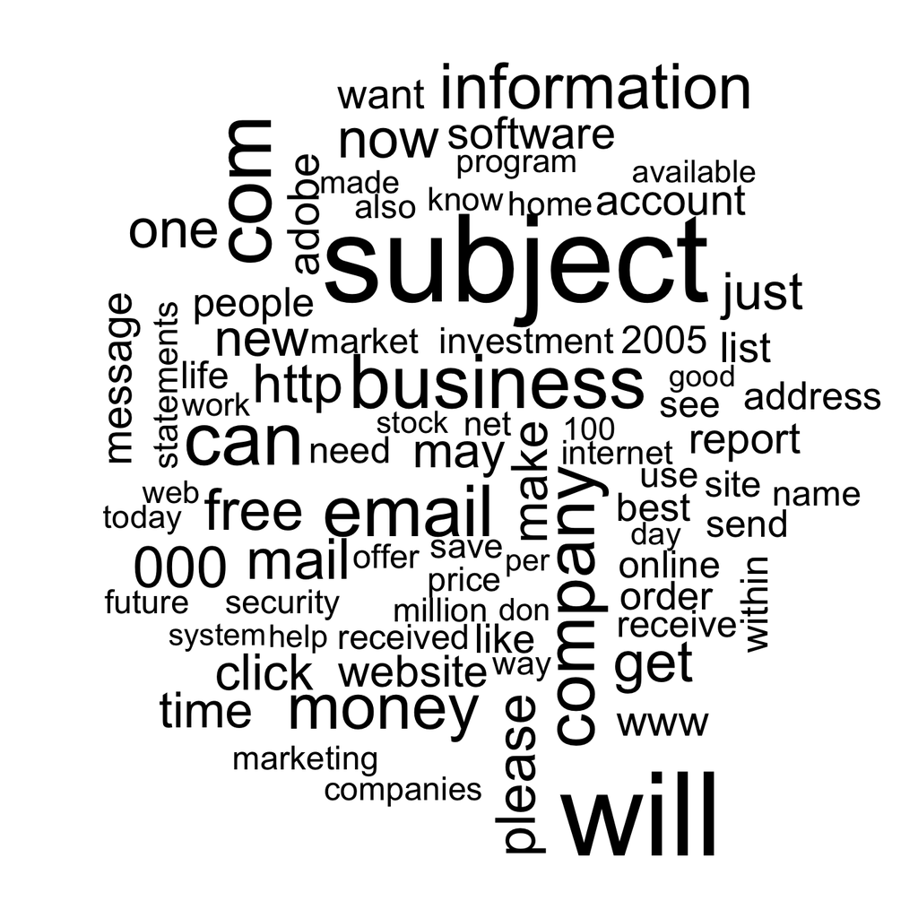

```r
# 学習データをクラスごとに分ける
spam <- subset(train_mail, class == "spam")
ham <- subset(train_mail, class == "ham")

# 迷惑メールと通常メールの単語をそれぞれ表示する
set.seed(123)
wordcloud(spam$text, max.words = 80)
```

迷惑メールでは、`subject`、`business`、`money`、`free` などがよく現れている。`subject` はメールの件名を示す表記で、このデータでは通常メールと迷惑メールのすべてに含まれるため、その有無は分類に役立たない。このような不要な表記を取り除く前処理が重要である。

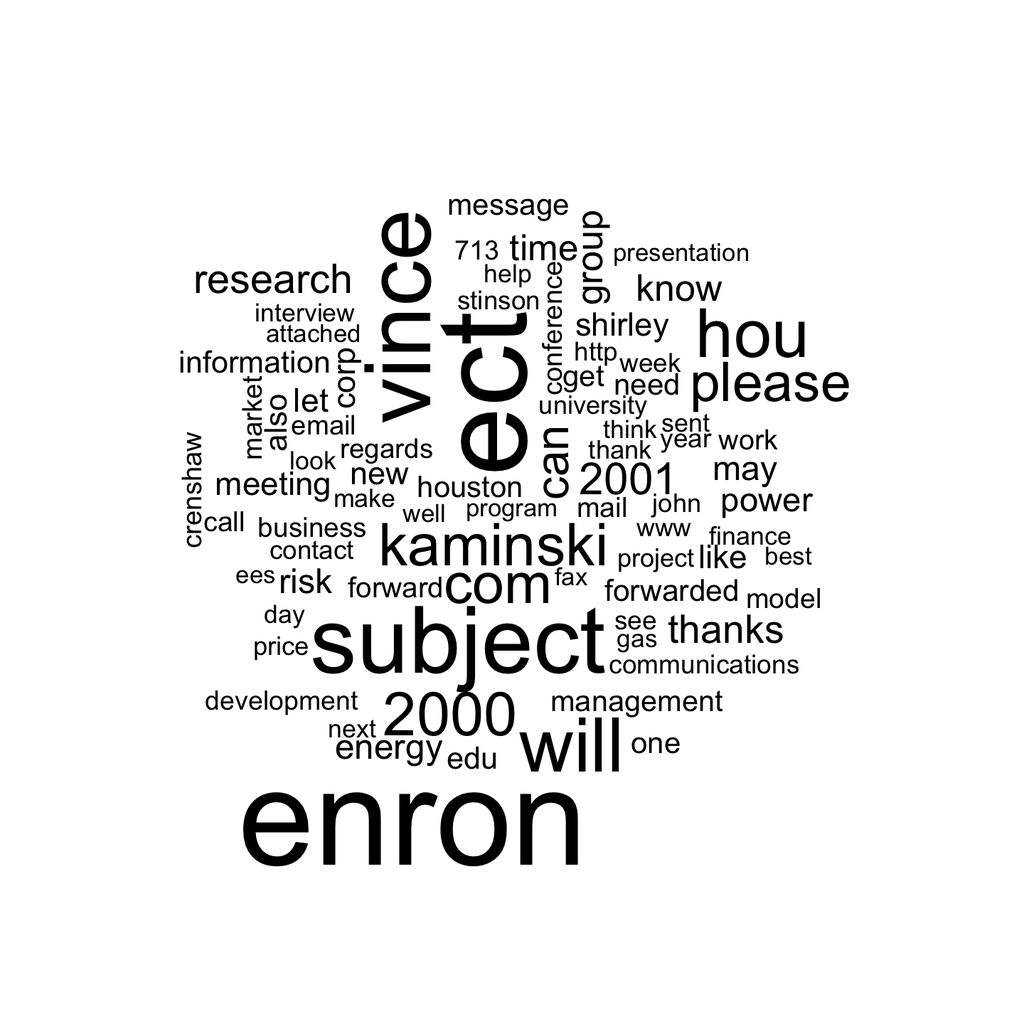

```r
wordcloud(ham$text, max.words = 80)
```

通常メールでは、`enron`、`subject`、`will`、`please` などがよく現れている。`enron` や人名などは、このデータの出所に関連する可能性があり、他のメールでも分類に役立つとは限らない。

大きく表示された単語を特徴量の候補にできる。ただし、迷惑メールにも頻繁に現れる単語は分類に役立つとは限らない。クラスごとの出現割合も比較して選ぼう。候補の選択やモデルの調整は学習データ内で行い、最後にテストデータで評価する。

例えば、次の表は単語を選ぶ考え方を示したものであり、数値は説明用の架空の例である。

| 単語 | 迷惑メールでの出現割合 | 通常メールでの出現割合 | 判断 |
| --- | --- | --- | --- |
| free | 30% | 5% | 分類に役立つ可能性がある |
| subject | 100% | 100% | 両クラスを区別できない |

# 5 まとめ

今回はNaive Bayesでメール本文を分類した。テキスト分類は重要な応用分野であり、Googleなども機械学習を迷惑メール対策に活用している。正解率は約81.2%で、k-NNやLogistic回帰の実習より低かったが、データが異なるためモデルの優劣を直接比較できない。テキスト分類では、前処理や単語の選択が予測性能に大きく影響する。正解率だけでなく、迷惑メールの見逃しも確認しよう。

Naive Bayesは、目的変数 $y$ が3種類以上のクラスを持つ場合にも使える。各クラスの事前確率と特徴量の条件付き確率から事後確率を求め、最も確率の高いクラスに分類する。また、特徴量 $X$ の種類に応じて分布を選ぶ。例えば、単語のあり／なしにはBernoulli分布、単語の出現回数にはMultinomial分布、連続値の特徴量には正規分布を用いるGaussian Naive Bayesがある。

単語を手動で選ぶには、**対象分野の知識や経験が必要**である。例えば、詐欺メールに特徴的な表現を見つけるには、犯罪学などの知識も役立つ。直感に頼らず単語を選ぶ方法として、Logistic回帰にL1正則化を加えたLasso Logistic回帰も使える。単語の係数を0にすることで特徴量を選択し、予測性能の改善につながる場合が多い。

参考：Koh, K., Kim, S.-J., & Boyd, S. (2007). [An Interior-Point Method for Large-Scale $\ell_1$-Regularized Logistic Regression](https://web.stanford.edu/~boyd/papers/l1_logistic_reg.html). *Journal of Machine Learning Research*, 8, 1519–1555.